# fresh start

DM

23/11/2016

- First, the list of questions:
1. get the data I obtain the data from the Pastor and Stambaught replication package
2. rewrite the model and see the differences in the variance predictions (direct vs var)
3. why and how gmm
4. run an easy example gmm, var

Progress

## 1.getting the data… DONE

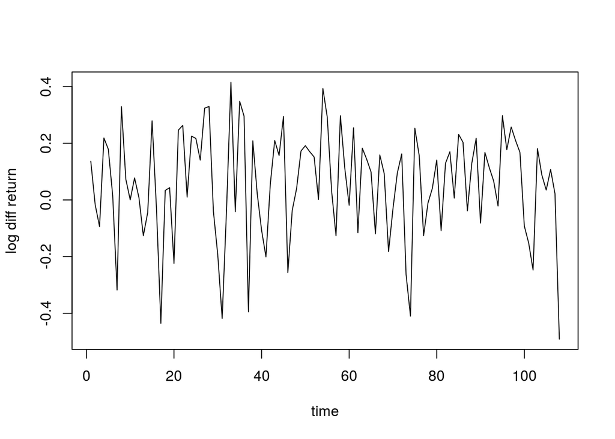

```r
y <- unlist(read.csv('return.csv', header = F)) # log difference in returns ?...!
x <- unlist(read.csv('x1.csv', header = F)) # don't knwo which data are those
y <- as.matrix(y)
x <- as.matrix(x)
T <- length(y)
plot(1:T, y, type = 'l', xlab = 'time', ylab = 'log diff return')
```

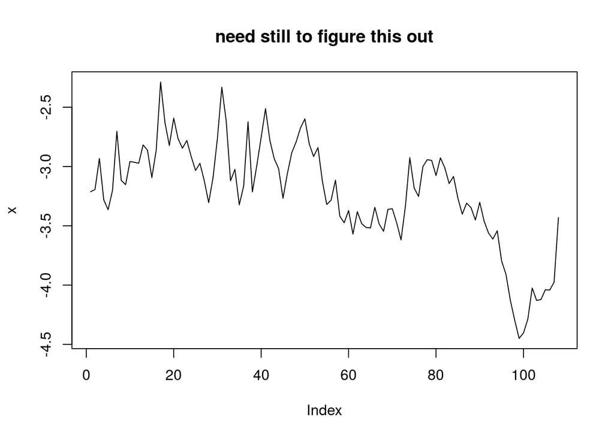

```r
plot(x, type = 'l', main = 'need still to figure this out')
```

## 2. rewtiting the models to see differences in predictions…

The eventual interest lies in the development of
$$\Sigma_{r}(k) \equiv \frac{1}{k} Var(r_{t, t+k}| \mathcal{I}_{t})$$
where $r_{t, t+ k} = \sum_{i = 1}^{k}r_{t+i}$

### VAR

A typical model goes
$$z_{t} = \begin{bmatrix} r_{t} - \mathbb{E}[r]\\x_{t} - \mathbb{E}[x] \end{bmatrix} =
\begin{bmatrix} 0 & \phi_{1, 2}\\ 0 & \phi_{2, 2} \end{bmatrix}
\begin{bmatrix} r_{t-1} - \mathbb{E}[r]\\x_{t-1} - \mathbb{E}[x] \end{bmatrix} + \nu_{t} \text{ , } \nu_{t} \sim \mathcal{N} (0, \Sigma)$$
We express the variance:
$$V(z_{t + 1} = z_{t + 2}... z_{t + k}|D_{t}) = \Sigma + (I + \Phi) \Sigma (I + \Phi)' + ... + (I + \Phi + ... + \Phi^{k}) \Sigma (I + \Phi + ... + \Phi^{k})'$$

Retrieving the nesessary matrix coefficients, we get the expression of interest:
$$\sigma_{r}^{2}(k) = \sigma_{1, 1}^{2} + 2 \phi_{1, 2} \sigma_{1, 2} \psi_{1}(k) + \phi_{1, 2}^{2} \sigma_{2, 2}^{2} \psi_{2}(k)$$
where both $\psi_{1}(k)$ and $\psi_{2}(k)$ are functions of $\phi_{2, 2}$. The decomposition of the variance is as follows:$\sigma_{1, 1}^{2}$ is the i.i.d component, $2 \phi_{1, 2} \sigma_{1, 2} \psi_{1}(k)$ is the mean reversion component (relying on $\sigma_{1, 2}$ being negative) and $\phi_{1, 2}^{2} \sigma_{2, 2}^{2} \psi_{2}(k)$ is the uncertainty about future predictors.

Now, we run this toy VAR. [for those curious to estimate the restricted VAR by hands](http://cadmus.eui.eu/bitstream/handle/1814/6918/ECO-2007-11.pdf)

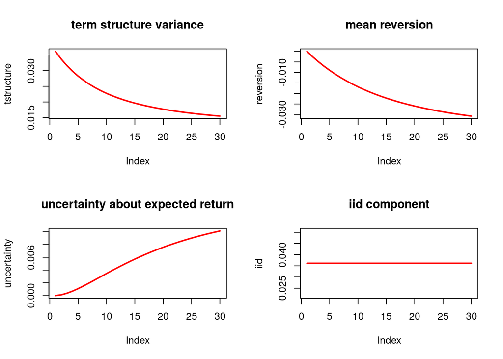

### Direct regression approach

## Here is a list of useful literature, with links

- Amit Goyal with his [website](http://www.hec.unil.ch/agoyal/) and his paper [Empirical Performance of Equity Premium Predictions](http://www.hec.unil.ch/agoyal/docs/Predictability_RFS.pdf) that is a major study on return predictability.
- For the estimation of dynamic system of equations, see Van Binsbergen and Koijen
- For publishing and some replication advice, see [this website](http://christophj.github.io/replicating)
- C.Favero’s working paper, which is the main reference.